# Stat 333 - Group 9 RMD

2025-11-23

```r
library(dplyr)
library(ggplot2)
library(car)
library(pROC)
library(corrplot)

setwd("C:/Users/mason/OneDrive/Desktop/2025-2026/Stats 333/Final Project")
getwd()

df_flights <- readRDS("df_flights.rds")
df_cancelled <- readRDS("df_cancelled.rds")
```

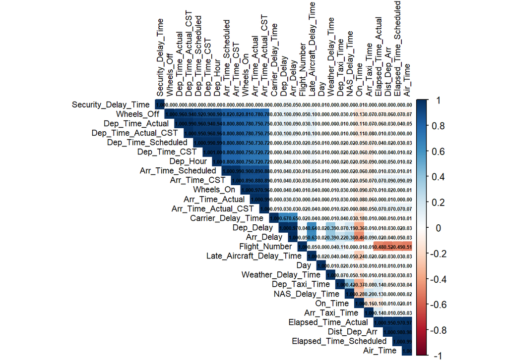

```r
Airline_Data <- read.csv("AirlineData.csv")
df <- data.frame(Airline_Data)


# CST Time Fixer ----------------------------------------------------------

### Converts all time into CST
# timevar: local time from original BTS data
# state: U.S. state in which the airport is located.
# city: city in which the airport is located.
# output: outputs the time in CST

CSTTimeFixer <- function(timevar,state,city) {
  ## Oddballs ##
  if(state == "AK") return(timevar + 300)
  if(state == "HI") return(timevar + 400)
  if(state == "PR") return(timevar - 200)

  if(state %in% c("CT","DE","DC","GA","IN","ME","MD","MA","MI","NH","NJ","NY","NC","OH",
                  "PA","RI","SC","VT","VA","WV")) return(timevar - 100)

  if(state == "FL") {
    return(ifelse(city != "Pensacola, FL",timevar-100,timevar))
  }

  if(state == "KY") {
    return(ifelse(city != "Paducah, KY",timevar-100,timevar))
  }
  # TN (half east coast) needs to be separated
  if(state == "TN"){
    return(ifelse(city == "Chattanooga, TN" | city == "Knoxville,TN",timevar-100,timevar))
  }


  if(state == "SD") {
    return(ifelse(city == "Rapid City, SD",timevar+100,timevar))
  }

  if(state == "TX") {
    return(ifelse(city == "El Paso, TX",timevar+100,timevar))
  }

  if(state %in% c("AZ","CO","ID","KS","MT","NM")) return(timevar + 100)
  if(state %in% c("CA","NV","OR","WA")) return(timevar+200)
  return(timevar)
}

# Data Cleaning  ----------------------------------------------------------

df$On_Time <- as.integer(df$Arr_Delay <= 0)

df$Dep_Time_CST <- mapply(CSTTimeFixer, df$Dep_Time_Scheduled, df$Dep_State, df$Dep_City)
df$Arr_Time_CST <- mapply(CSTTimeFixer, df$Arr_Time_Scheduled, df$Arr_State, df$Arr_City)
df$Dep_Time_Actual_CST <- mapply(CSTTimeFixer, df$Dep_Time_Actual, df$Dep_State, df$Dep_City)
df$Arr_Time_Actual_CST <- mapply(CSTTimeFixer, df$Arr_Time_Actual, df$Arr_State, df$Arr_City)


df_flights <- df[df$Cancelled == 0, ]
df_cancelled <- df[df$Cancelled == 1, ]
df_cancelled$Partial_Move <- !is.na(df_cancelled$Wheels_Off)

df_flights$Dep_Hour <- df_flights$Dep_Time_CST %/% 100

delay_cols <- c("Carrier_Delay_Time","Weather_Delay_Time","NAS_Delay_Time",
                "Security_Delay_Time","Late_Aircraft_Delay_Time")

df_flights[delay_cols] <- lapply(df_flights[delay_cols], function(x) ifelse(is.na(x),0,x))

saveRDS(df_flights, "df_flights.rds")
saveRDS(df_cancelled, "df_cancelled.rds")

# Correlation---------------------------------------------------------------

num_cols <- sapply(df_flights, is.numeric)
numeric_data <- df_flights[, num_cols]

numeric_data_nonzero <- numeric_data[, sapply(numeric_data, function(x) sd(x, na.rm = TRUE) != 0)]
cor_matrix <- cor(numeric_data_nonzero, use = "pairwise.complete.obs")
cor_matrix


corrplot(cor_matrix,
         method = "color",
         type = "upper",
         tl.col = "black",
         tl.cex = 0.7,
         addCoef.col = "black",
         number.cex = 0.4,
         order = "hclust")
```

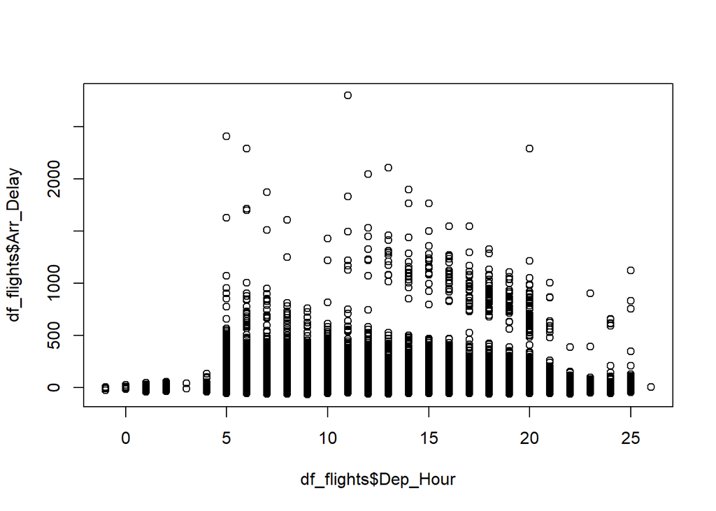

```r
plot(df_flights$Dep_Hour, df_flights$Arr_Delay)
```

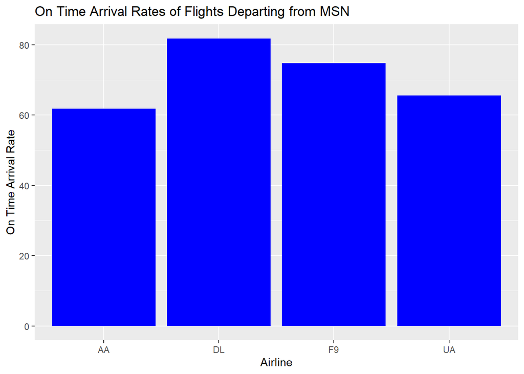

```r
#Goal 1: Which airline should passengers book when flying out of MSN in order to arrive on time?
#--------------------------------------------
df_flights <- readRDS("df_flights.rds")
df_cancelled <- readRDS("df_cancelled.rds")
df_flights$Dep_Hour <- df_flights$Dep_Time_CST %/% 100

msn <- df_flights[df_flights$Dep_Airport == "MSN",]
msn_arrive_on_time <- msn %>% group_by(Airline) %>% summarise(Flights = n(), Flights_On_Time = sum(On_Time, na.rm = TRUE), Rate_of_Flights_On_Time = round(mean(On_Time, na.rm = TRUE) * 100, 2)) %>% arrange(desc(Rate_of_Flights_On_Time))

msn_arrive_on_time

ggplot(msn_arrive_on_time, aes(x = Airline, Rate_of_Flights_On_Time, y = Rate_of_Flights_On_Time)) + geom_col(fill = "blue") + labs(title = "On Time Arrival Rates of Flights Departing from MSN", x = "Airline", y = "On Time Arrival Rate")
```

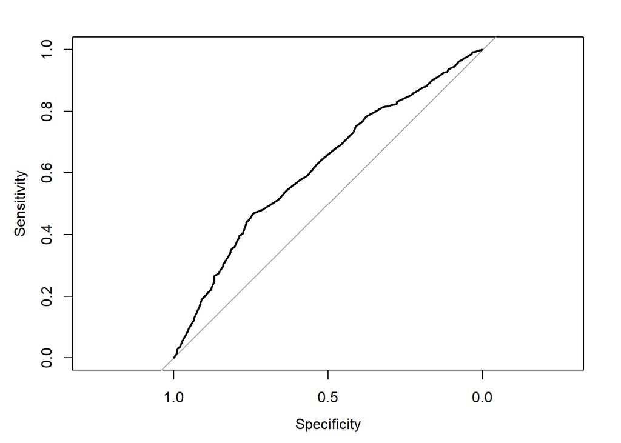

```r
modelt <- glm(On_Time ~ Airline + Dep_Hour + Dist_Dep_Arr, data = msn, family = binomial(link = "logit"))
summary(modelt)

vif(modelt)

Anova(modelt, type = "III")

rocmodelt <- roc(msn$On_Time ~ fitted(modelt))
plot(rocmodelt)
```

```r
auc(rocmodelt)
```

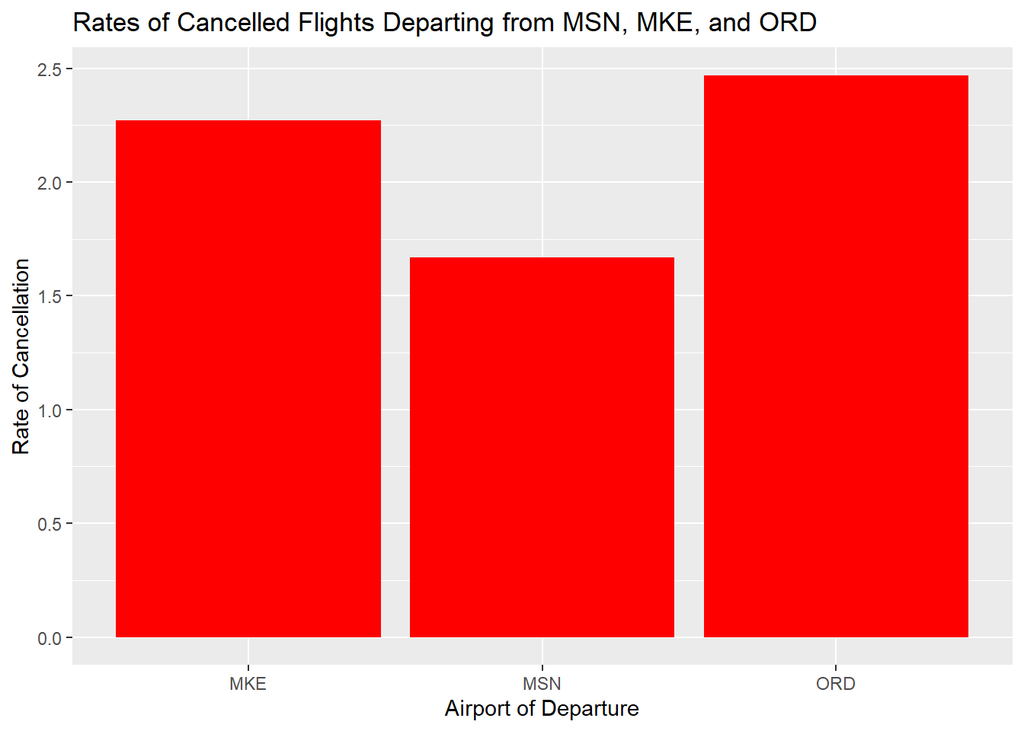

```r
#Goal 2: Which airport of the 3 (MSN, MKE, ORD) has the lowest rate of cancelled flights?
#----------------------------------------------
airports <- c("MSN", "MKE", "ORD")
df_airports <- df %>% filter(Dep_Airport %in% airports)
cancel_flights <- df_airports %>% group_by(Dep_Airport) %>% summarise(Total_Flights = n(), Cancelled_Flights = sum(Cancelled == 1, na.rm = TRUE), Rate_of_Cancelled_Flights = round(mean(Cancelled == 1, na.rm = TRUE) * 100, 2)) %>% arrange(Rate_of_Cancelled_Flights)

cancel_flights

ggplot(cancel_flights, aes(x = Dep_Airport, Rate_of_Cancelled_Flights, y = Rate_of_Cancelled_Flights)) + geom_col(fill = "red") + labs(title = "Rates of Cancelled Flights Departing from MSN, MKE, and ORD", x = "Airport of Departure", y = "Rate of Cancellation")
```

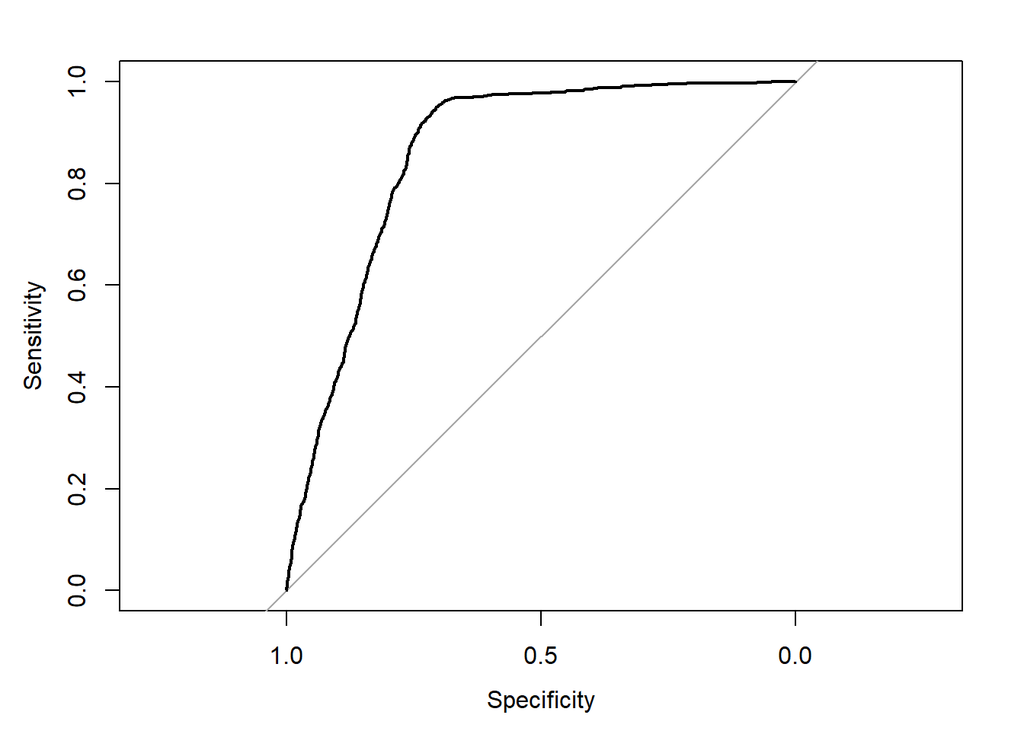

```r
modelc <- glm(Cancelled ~ Dep_Airport + Airline + Month + Dist_Dep_Arr, data = df_airports, family = binomial)
summary(modelc)

vif(modelc)

Anova(modelc, type = "III")

rocmodelc <- roc(df_airports$Cancelled ~ fitted(modelc))
plot(rocmodelc)
```

```r
auc(rocmodelc)
```

> Goal 3 Which NYC Airport is best on which day of the week? The code for summarizing flight data by weekday was adapted with the help of ChatGPT (OpenAI, 2025).

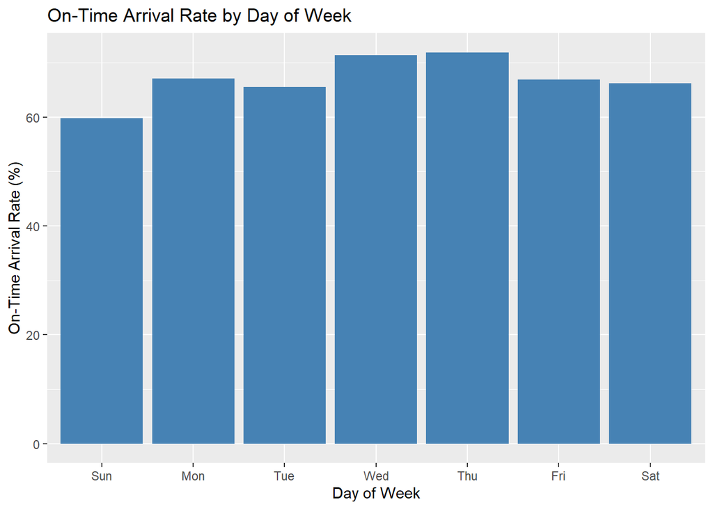

```r
df_flights$Weekday <- weekdays(as.Date(df_flights$Flight_Date))

weekday_on_time <- df_flights %>%
  group_by(Week) %>%
  summarise(Rate_On_Time = mean(On_Time, na.rm = TRUE) * 100) %>%
  mutate(Week = factor(Week, levels = c("Sun","Mon","Tue","Wed","Thu","Fri","Sat"), ordered = TRUE))

ggplot(weekday_on_time, aes(x = Week, y = Rate_On_Time)) +
  geom_col(fill = "steelblue") +
  labs(title = "On-Time Arrival Rate by Day of Week",
       x = "Day of Week",
       y = "On-Time Arrival Rate (%)")
```

> Modeling

```r
df_flights$Late <- ifelse(df_flights$Arr_Delay > 0, 1, 0)

df_flights$Airline <- as.factor(df_flights$Airline)
df_flights$Week <- as.factor(df_flights$Week)

model <- glm(On_Time ~  Week, data = df_flights, family = binomial)
summary(model)

odds_ratios <- exp(coef(model))
odds_ratios
```

> General model that uses Friday as refrence level, can be applied to a rule of thumb on what days are most likely to have delays. The model shows that on-time flight odds vary by day of the week. Thursday has the highest odds of being on time (Odds Ratio ≈ 1.27), followed by Wednesday (Odds Ratio ≈ 1.24). Sunday has the lowest odds (Odds Ratio ≈ 0.74), indicating it is the day most likely to experience delays. Monday, Tuesday, and Saturday are similar to Friday.

> Now lets apply this idea to NYC airports “JFK”, “LGA”, “EWR”. To determine what day of the week you should fly out of each airport.

```r
ny_airports <- c("JFK", "LGA", "EWR")
df_ny <- df_flights[df_flights$Dep_Airport %in% ny_airports, ]
df_ny$Week <- factor(df_ny$Week, levels = c("Mon", "Tue", "Wed", "Thu", "Fri", "Sat", "Sun"))
```

```r
ny_model <- glm(On_Time ~ Week * Dep_Airport, family = binomial, data = df_ny)
summary(ny_model)
```

> Note that a Monday flight out of EWR is our refrence level for this model.

```r
new_data <- expand.grid(
  Week = c("Mon", "Tue", "Wed", "Thu", "Fri", "Sat", "Sun"),
  Dep_Airport = c("EWR", "JFK", "LGA")
)

new_data$log_odds <- predict(ny_model, newdata = new_data, type = "link")
new_data
```

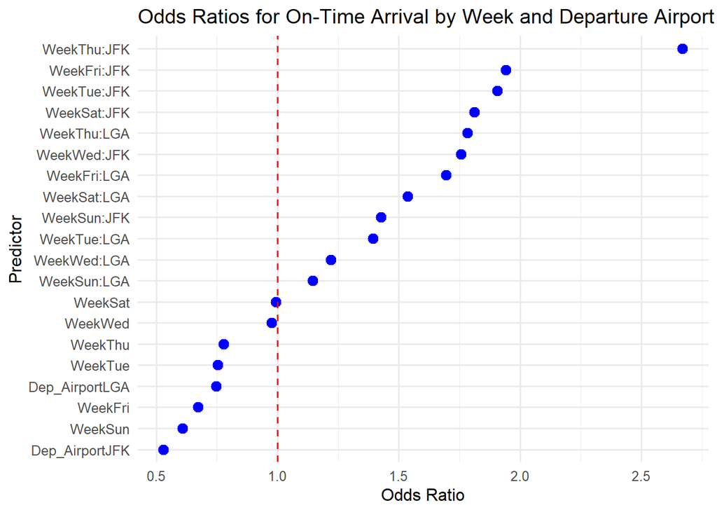

```r
odds_ratios <- exp(coef(ny_model))
or_table <- cbind(Odds_Ratio = odds_ratios)
or_table

odds_data <- data.frame(
  Term = c("WeekTue","WeekWed","WeekThu","WeekFri","WeekSat","WeekSun",
           "Dep_AirportJFK","Dep_AirportLGA",
           "WeekTue:JFK","WeekWed:JFK","WeekThu:JFK","WeekFri:JFK","WeekSat:JFK","WeekSun:JFK",
           "WeekTue:LGA","WeekWed:LGA","WeekThu:LGA","WeekFri:LGA","WeekSat:LGA","WeekSun:LGA"),
  OR = c(0.7548762,0.9759136,0.7784785,0.6722384,0.9937804,0.6096576,
         0.5305233,0.7475083,
         1.9054199,1.7568545,2.6688284,1.9418690,1.8116591,1.4263173,
         1.3928646,1.220819,1.7832771,1.6941742,1.5363041,1.1462670)
)


ggplot(odds_data, aes(x = reorder(Term, OR), y = OR)) +
  geom_point(color = "blue", size = 3) +
  geom_hline(yintercept = 1, linetype = "dashed", color = "red") +
  coord_flip() +
  labs(
    title = "Odds Ratios for On-Time Arrival by Week and Departure Airport",
    x = "Predictor",
    y = "Odds Ratio"
  ) +
  theme_minimal(base_size = 12)
```

> Model Diagnostics (Multicolinearity/Effectiveness)

```r
vif(ny_model)

Anova(ny_model, type = "III")
```

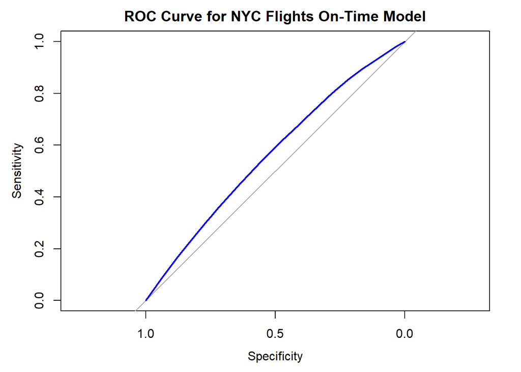

```r
pred_probs <- predict(ny_model, type = "response")

ny_roc <- roc(df_ny$On_Time ~ pred_probs)

plot(ny_roc, main = "ROC Curve for NYC Flights On-Time Model", col = "blue", lwd = 2)
```

```r
auc(ny_roc)
```

> Key Takeaway: There are statistically distinguishable effects of departure airport and day of the week on the probability of a flight arriving on time. However, these effects are small, and the model has limited predictive power for individual flights.